# DATA 152 HW4 - Tyler Bontrager

Due February 22, 2023 @ 11:59pm

** CHANGE YOUR NAME IN THE HEADER and then complete the following: **

## QUESTION 1

### 1A

Simulate 10000 standard normal random variables by running `rnorm(10000,0,1)`. Name this variable “normSim”.

```r
normSim = rnorm(10000,0,1)
```

### 1B

Create a histogram of your data.

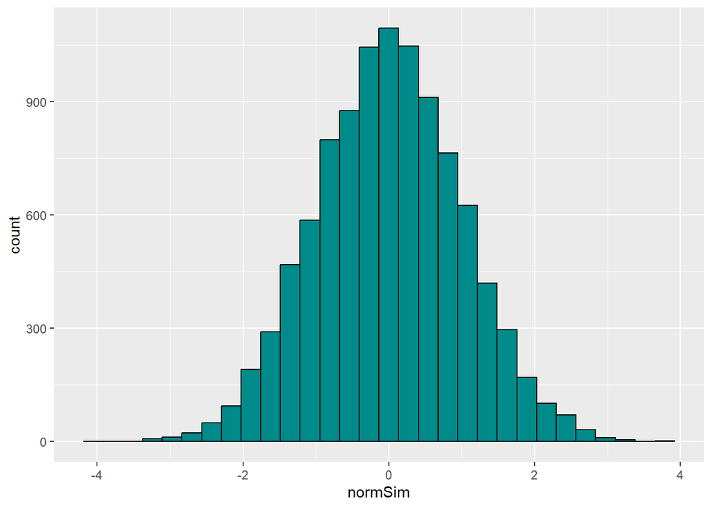

```r
tibble(normSim) %>%
  ggplot(aes(x=normSim)) +
  geom_histogram(color="black",fill="cyan4")
```

### 1C

What percent of your observations fall 2 standard deviations below the mean? In other words, what percent of your z scores (i.e. standardized values) are less than 2?

```r
nsTibble = tibble(normSim)
mean(normSim)
```

```
## [1] 0.0001960606
```

```r
z = (normSim-mean(normSim))/sd(normSim)

nsTibble %>%
  mutate(
    z_score = z
  )
```

```
## # A tibble: 10,000 × 2
##    normSim z_score
##      <dbl>   <dbl>
##  1 -0.431  -0.432
##  2  2.08    2.09
##  3 -0.130  -0.130
##  4  0.896   0.897
##  5  0.0334  0.0333
##  6  0.214   0.214
##  7 -1.46   -1.47
##  8  0.415   0.415
##  9 -1.47   -1.47
## 10  0.663   0.664
## # … with 9,990 more rows
```

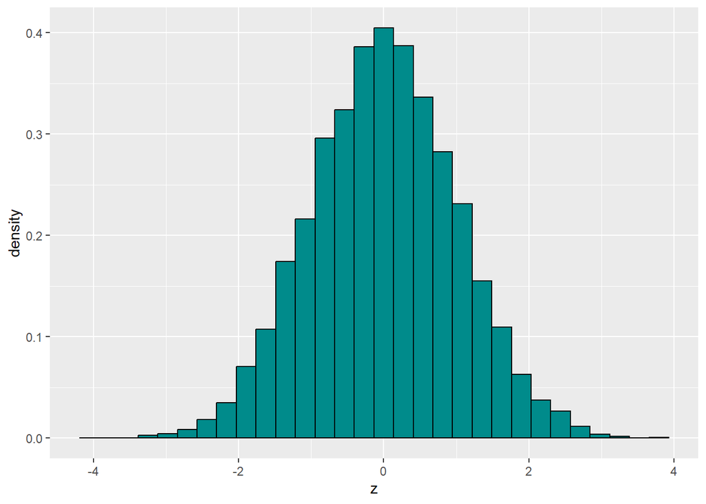

```r
nsTibble %>%
  ggplot(aes(x=z,y=..density..)) +
  geom_histogram(color="black",fill="cyan4")
```

```r
pnorm(-2,0,1)
```

```
## [1] 0.02275013
```

ANSWER: 2.28% (did I do this correctly?)

### 1D

Use `pnorm` to calculate the exact probability a standard normal variable is less than -2.

```r
pnorm(-2,0,1) #?
```

```
## [1] 0.02275013
```

ANSWER: 2.28%?

### 1E

Why are your answers in 1C and 1D different?

ANSWER: I couldn’t seem to find the observed number of z scores 2 sds below the mean, but I’d imagine they’d be off because our data isn’t supposed to be perfectly normal.

## QUESTION 2

In triathlons, it is common for racers to be placed into age and gender groups. Friends Jed and Heather both completed the Hermosa Beach Triathlon, where Jed competed in the “Men, ages 30-34” group while Heather competed in the “Women, Ages 25-29” group. Jed completed the race in 1:22:29 (4948 seconds), while Heather completed the race in 1:31:53 (5513 seconds). They are curious about how they did within their respective groups. Here’s information about the performance of their groups:

- The finishing times of the “Men, ages 30-34” group has a mean of 4313 seconds with a standard deviation of 583 seconds.
- The finishing times of the “Women, Ages 25-29” group has a mean of 5261 seconds with a standard deviation of 807 seconds. The distributions of finishing times for both groups are approximately Normal.

### 2A

What are the z-scores for Jed’s and Heather’s finishing times?

```r
jz = (4948-4313)/583
hz = (5513-5261)/807

#Jed's Z-score:
jz
```

```
## [1] 1.089194
```

```r
#Heather's Z-score:
hz
```

```
## [1] 0.3122677
```

ANSWER: Jed: 1.09; Heather: 0.31

### 2B

Did Jed or Heather perform better in their respective groups? Explain your reasoning.

### 2C

What percent of triathletes performed better than Heather? Remember: a better performance corresponds to a faster finish.

```r
1-pnorm(hz,0,1)
```

```
## [1] 0.3774186
```

### 2D

What percent of triathletes performed better than Jed? Remember: a better performance corresponds to a faster finish.

```r
1-pnorm(jz,0,1)
```

```
## [1] 0.1380342
```

### 2E

Use the 68-95-99.7 Rule to calculate the range of times that encompasses 95% of all run times for the “Women, Ages 25-29” group.

```r
0-2*1
```

```
## [1] -2
```

```r
0+2*1
```

```
## [1] 2
```

```r
5261-2*807
```

```
## [1] 3647
```

```r
5261+2*807
```

```
## [1] 6875
```

ANSWER: 95% of run times are expected to be between -2 and 2 standard deviations from the mean. This corresponds to between 3647 and 6875 seconds.

## QUESTION 3

The average daily high temperature in June in LA is 77F with a standard deviation of 5F. Suppose that the temperatures in June closely follow a normal distribution.

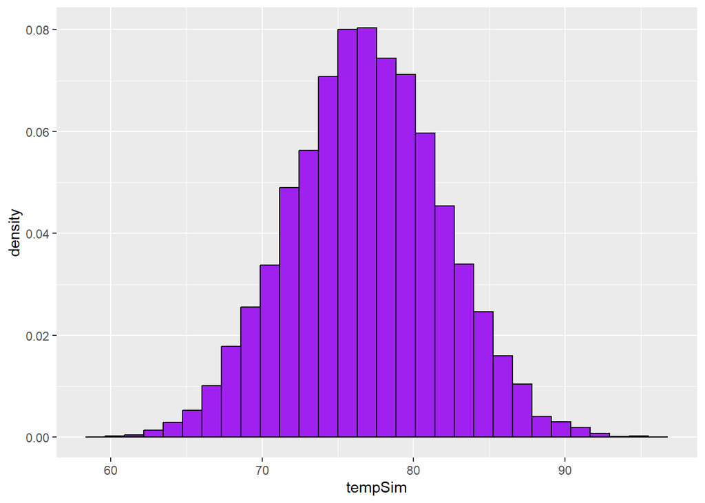

```r
tempSim = rnorm(10000,77,5)
tibble(tempSim) %>%
  ggplot() +
  geom_histogram(aes(x=tempSim,y=..density..),color="black",fill="purple")
```

```r
tempmean=77
tempsd=5
```

ANSWER: Yes?

### 3A

What is the probability of observing an 83F temperature or higher in LA during a randomly chosen day in June?

```r
1-pnorm(83,tempmean,tempsd)
```

```
## [1] 0.1150697
```

ANSWER: 11.5%

### 3B

How cool are the coldest 10% of the days during June in LA?

```r
qnorm(.10,tempmean,tempsd)
```

```
## [1] 70.59224
```

ANSWER: 70.6 degF

## QUESTION 4

Cholesterol levels for women aged 20 to 34 follow an approximately normal distribution with mean 185 milligrams per deciliter (mg/dl). Women with cholesterol levels above 220 mg/dl are considered to have high cholesterol. About 18.5% of women fall into the “high cholesterol” category. What is the standard deviation of cholesterol levels for women aged 20 to 34?

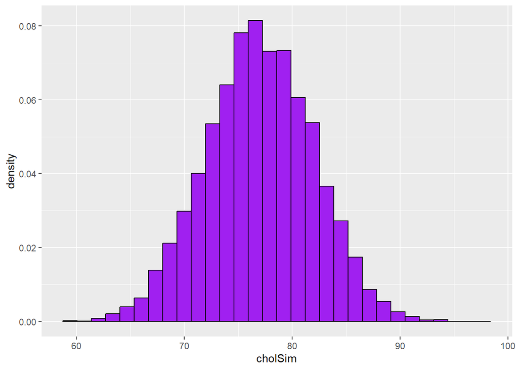

```r
cholSim = rnorm(10000,77,5)
tibble(cholSim) %>%
  ggplot() +
  geom_histogram(aes(x=cholSim,y=..density..),color="black",fill="purple")
```

```r
cholmean=185
#cholstd = ?
#standardize

# z=(x-u)/o
# 18.5% is 1 standard deviation above the mean => z=1
# 1=(x-u)/o
# o=(x-u)
# o=(220-185) => o=35 mg/dL
```

ANSWER: 35 mg/dL

*INSTRUCTIONS TO SUBMIT* Knit this into an html document and submit BOTH the Rmd and the html file in WISE. Name both files using this naming convention: LASTNAME_FIRSTNAME_DATA152_HW4.Rmd (or html). For example, Dr. Gore’s submissions would be named GORE_KRISTEN_DATA154_HW1.Rmd and GORE_KRISTEN_DATA152_HW4.html. Failure to follow these instructions will result in a 10-point deduction.